# SHARP Multiomics Workshop Session 2: Interactions

Andre Kim, Yinqi Zhao, Jim Gauderman

2025-05-27

# Introduction

Apply methods discussed in lecture to search for GxE interactions in the **HELIX** data set

- Data processing + exposure main effects
- Example of interaction testing
- Introduction to GWIS using `BinaryDosage`/`GxEScanR`
- Conduct scan of **maternal alcohol** and childhood BMI
- Conduct scan of **maternal smoking** and childhood BMI (Exercise)

# HELIX study

The HELIX study is a collaborative project across six longitudinal population-based birth cohort studies in six European countries (France, Greece, Lithuania, Norway, Spain, and the United Kingdom).

**For the lab - subcohort of 1,301 mother-child pairs**

- exposure + genomic data from children 6-11 years old
- N = 1,122 with complete data
- investigate interactions between fetal alcohol/tobacco exposure and genetic variants, and their influence on childhood BMI

Note that the genomic data used in this example is simulated.

**Variables of interest:**

- **hs_bmi_c_cat (Outcome)** : Body mass index, dichotomized
  - 0 = Thinness/Normal
  - 1 = Overweight/Obese (WHO reference)
- **e3_alcpreg_yn_None (Exposure)** - Maternal alcohol use during pregnancy
  - 0 = Never
  - 1 = Ever
- **h_mbmi_None** - Maternal pre-pregnancy body mass index
  - kg/m2 (continuous)
- **e3_sex_None** - Sex
  - 0 = Female
  - 1 = Male
- **h_age_None** - Maternal age
  - years (continuous)
- **h_cohort** - Cohort country
  - 1 = France
  - 2 = Greece
  - 3 = Lithuania
  - 4 = Norway
  - 5 = Spain
  - 6 = UK
- **h_edumc_None** - Maternal education
  - 1 = primary school
  - 2 = secondary school
  - 3 = university degree or higher
- **ethn_PC1/2** - two principal components (ethnicity)

## Data processing

`HELIX.MultiAssayExperiment` - R object that stores multiple data sets measured on the same individuals (e.g. exposure/outcome data, genomic, methylation, metabolites, etc)

Begin by obtaining variables of interest, combine into a `data.frame`

```r
# ---- Load RData containing HELIX MultiAssayExperiment object ---- #
# load.Rdata2(filename, path=getwd())
# assumes following data is in the current working directory
load("./data/HELIX.MultiAssayExperiment.RData")

# ---- specify variable names to extract ---- #
outcome.Name <- "hs_bmi_c_cat"
exposure.Name <- "e3_alcpreg_yn_None"
covariate.Names <- c("h_mbmi_None","e3_sex_None","h_age_None","h_cohort","h_edumc_None","ethn_PC1","ethn_PC2")
snp.Names <- paste("SNP", 1:1000, sep=".")
# putting it all together
variables <- c(covariate.Names, exposure.Name, "h_ethnicity_cauc", snp.Names)

# ---- extract variables from HELIX.MultiAssayExperiment ---- #
# 1) select variables to keep
# 2) `intersectionColumns` selects only individuals with complete data (N = 1,122)
# 3) `wideFormat` returns as a data.frame
# d <- wideFormat(intersectColumns(helix_ma[variables, ,]), colDataCols=outcome.Name)
# saveRDS(d, "d_alcohol.rds")
# assumes following file is in /interaction/data within current working directory
d <- readRDS("./data/d_alcohol.rds")

# ---- Genotype design matrix ---- #
X <- d[,grep("SNP", names(d))]
names(X) <- snp.Names
X <- as.matrix(X)

# ---- Epi data.frame ---- #
dataset <- data.frame(d[,c("primary", "hs_bmi_c_cat", "lifestyles_e3_alcpreg_yn_None",
"covariates_h_mbmi_None", "covariates_e3_sex_None", "covariates_h_age_None",
"covariates_h_cohort", "covariates_h_edumc_None", "proteome.cov_ethn_PC1",
"proteome.cov_ethn_PC2", "proteome.cov_h_ethnicity_cauc")])

# Rename columns for this example
names(dataset) <- c("primary", "hs_bmi_c_cat", "e3_alcpreg_yn_None", "h_mbmi_None", "e3_sex_None", "h_age_None", "h_cohort", "h_edumc_None", "ethn_PC1", "ethn_PC2", "h_ethnicity_cauc")

# Dichotomize outcome variable
dataset$hs_bmi_c_cat <- factor(ifelse(as.numeric(dataset$hs_bmi_c_cat)>=3, 1, 0), label = c("Thin/Normal", "Overweight/Obese"))

# Code variables properly (numeric vs factor)
dataset[, c("h_mbmi_None", "h_age_None", "ethn_PC1", "ethn_PC2")] <- lapply(dataset[, c("h_mbmi_None", "h_age_None", "ethn_PC1", "ethn_PC2")], as.numeric)
dataset[, c("e3_alcpreg_yn_None", "e3_sex_None", "h_cohort")] <- lapply(dataset[, c("e3_alcpreg_yn_None", "e3_sex_None", "h_cohort")], factor)
dataset$h_edumc_None <- factor(dataset$h_edumc_None, label = c("Primary school", "Secondary school", "University degree or higher"))

# Other variables for analysis (for convenience)
N <- nrow(d) # number of individuals in the analysis
P <- ncol(X)  # number of SNPs in the matrix X
```

## Descriptive statistics

```r
# various ways of generating descriptive stats, personally using `table1` package

library(table1)
label(dataset$e3_alcpreg_yn_None) <- "Maternal alcohol during pregnancy"
label(dataset$h_age_None) <- "Maternal age"
label(dataset$e3_sex_None) <- "Child sex"
label(dataset$h_mbmi_None) <- "Maternal pre-pregnancy BMI"
label(dataset$h_edumc_None) <- "Maternal education"

# run table1 function
table1(~ e3_alcpreg_yn_None +
         h_age_None +
         e3_sex_None +
         h_edumc_None +
         h_mbmi_None | hs_bmi_c_cat, data=dataset)
```

|  | Thin/Normal (N=786) | Overweight/Obese (N=336) | Overall (N=1122) |
| --- | --- | --- | --- |
| Maternal alcohol during pregnancy |  |  |  |
| 0 | 524 (66.7%) | 250 (74.4%) | 774 (69.0%) |
| 1 | 262 (33.3%) | 86 (25.6%) | 348 (31.0%) |
| Maternal age |  |  |  |
| Mean (SD) | 30.6 (4.70) | 31.0 (5.26) | 30.7 (4.87) |
| Median [Min, Max] | 31.0 [16.0, 43.5] | 31.0 [16.0, 43.5] | 31.0 [16.0, 43.5] |
| Child sex |  |  |  |
| female | 366 (46.6%) | 157 (46.7%) | 523 (46.6%) |
| male | 420 (53.4%) | 179 (53.3%) | 599 (53.4%) |
| Maternal education |  |  |  |
| Primary school | 110 (14.0%) | 50 (14.9%) | 160 (14.3%) |
| Secondary school | 248 (31.6%) | 142 (42.3%) | 390 (34.8%) |
| University degree or higher | 428 (54.5%) | 144 (42.9%) | 572 (51.0%) |
| Maternal pre-pregnancy BMI |  |  |  |
| Mean (SD) | 24.4 (4.87) | 26.8 (5.39) | 25.1 (5.15) |
| Median [Min, Max] | 23.4 [16.2, 44.8] | 25.4 [17.2, 45.5] | 24.1 [16.2, 45.5] |

## Univariate association tests

```r
univariate_vars <- c("e3_alcpreg_yn_None", "h_age_None", "e3_sex_None", "h_edumc_None", "h_mbmi_None")

univariate.results <- t(sapply(univariate_vars, FUN=function(p) {  # using index p facilitate write
  x <- dataset[,p]
  reg <- glm(dataset$hs_bmi_c_cat ~ as.numeric(x), family=binomial)    # perform logistic regression
  s.reg <- summary(reg)                 # get the summary for the regression
  c.reg <- s.reg$coef[2,]               # select the coefficients for the exposure
  return(c.reg)
}, simplify=T))
univariate.results <- data.frame(univariate_vars,univariate.results)
names(univariate.results) <- c("Variable","Estimate", "SD","Z.Statistic", "P-value")
rownames(univariate.results) <- NULL
univariate.results$`P-value` <-  formatC(univariate.results$`P-value`, format = "e", digits = 2)


kable(univariate.results, digits = 2) %>%
  kable_styling(bootstrap_options = c("striped", "hover"), full_width = F, position = 'left')
```

| Variable | Estimate | SD | Z.Statistic | P-value |
| --- | --- | --- | --- | --- |
| e3_alcpreg_yn_None | -0.37 | 0.15 | -2.56 | 1.05e-02 |
| h_age_None | 0.02 | 0.01 | 1.19 | 2.35e-01 |
| e3_sex_None | -0.01 | 0.13 | -0.05 | 9.60e-01 |
| h_edumc_None | -0.24 | 0.09 | -2.65 | 7.95e-03 |
| h_mbmi_None | 0.09 | 0.01 | 6.83 | 8.75e-12 |

## Genomic data

Simulated 1000 SNPs

### Plot of genetic ancestry (PCA)

PC1 vs PC2. Note clustering of NHW vs Others

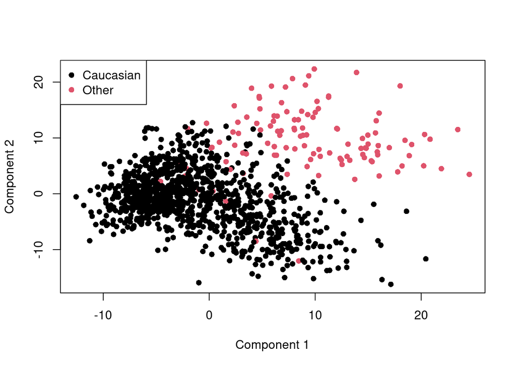

```r
plot(d$proteome.cov_ethn_PC1, d$proteome.cov_ethn_PC2, pch=16, col=ifelse(d$proteome.cov_h_ethnicity_cauc=="yes", 1, 2),
     xlab="Component 1", ylab="Component 2")
legend(x="topleft", legend=c("Caucasian", "Other"), col=c(1,2), pch=16)
```

### Correlation matrix for local genomic region

Simulated correlated structure to approximate real data structure

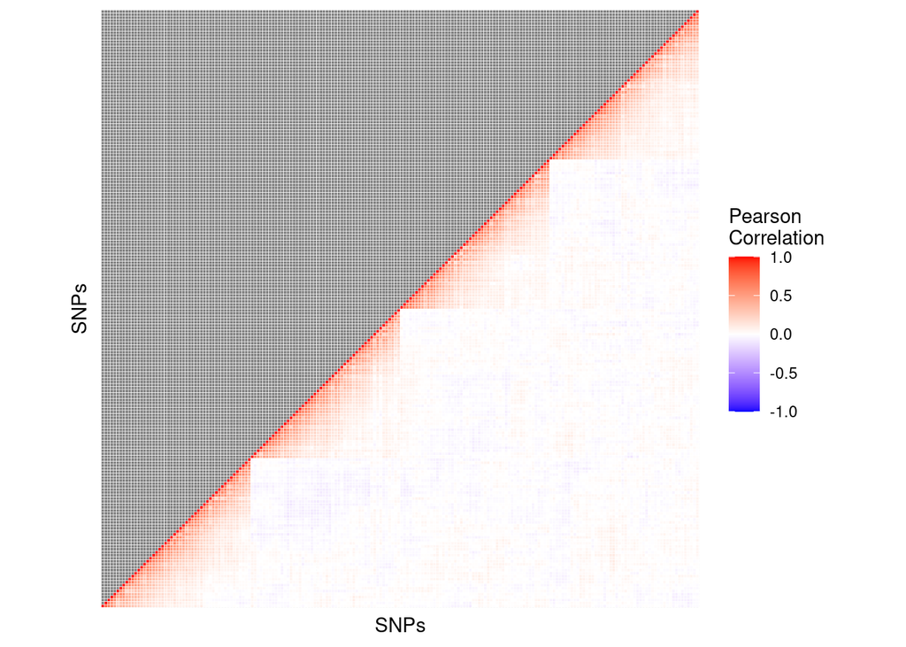

```r
cormat <- round(cor(X[,1:(P/5)], use="complete.obs"), 2)
cormat[lower.tri(cormat)]<- NA
melted_cormat <- melt(cormat)
ggplot(data = melted_cormat, aes(Var2, Var1, fill = value))+
  geom_tile(color = "white")+
  scale_fill_gradient2(low = "blue", high = "red", mid = "white",
                       midpoint = 0, limit = c(-1,1), space = "Lab",
                       name="Pearson\nCorrelation") +
  theme_minimal()+
  theme(axis.text.x = element_blank(), axis.text.y = element_blank())+
  labs(y= "SNPs", x = "SNPs")+
  coord_fixed()
```

# G x Maternal alcohol use and childhood BMI

#### **Question: is there effect heterogeneity for the association of maternal alcohol consumption and childhood BMI by germline genetics?**

## Simple interaction model

Most commonly used method for testing for interaction - fit traditional logistic regression model with interaction term in the form
$$logit\left(P(D=1|G,E)\right) = \alpha +
\beta_EE + \beta_GG + \beta_{GxE}G\times E$$

$H0:\beta_{GxE} = 0$ is equivalent to testing $\frac{OR_{GxE}}{OR_G \times OR_E} = 1$ e.g. departure from multiplicative scale interaction

Example - `SNP.1` x `e3_alcpreg_yn_None`

**NOTE** - we will adjust all models by

- maternal age
- maternal pre-pregnancy BMI
- maternal education
- study country
- sex
- ancestry (2 principal components)

```r
SNP.1 <- X[,1] # getting SNP from genotype design matrix

model <- glm(hs_bmi_c_cat ~ e3_alcpreg_yn_None * SNP.1 + h_age_None + h_mbmi_None +  h_cohort + h_edumc_None + e3_sex_None + ethn_PC1 + ethn_PC2, data = dataset, family = 'binomial')

kable(tidy(model), digits = 2) %>%
  kable_styling(bootstrap_options = c("striped", "hover"), full_width = F, position = 'left')
```

| term | estimate | std.error | statistic | p.value |
| --- | --- | --- | --- | --- |
| (Intercept) | -5.15 | 0.68 | -7.56 | 0.00 |
| e3_alcpreg_yn_None1 | -0.24 | 0.20 | -1.22 | 0.22 |
| SNP.1 | 0.02 | 0.14 | 0.15 | 0.88 |
| h_age_None | 0.02 | 0.02 | 1.57 | 0.12 |
| h_mbmi_None | 0.11 | 0.01 | 7.64 | 0.00 |
| h_cohort2 | 1.07 | 0.32 | 3.36 | 0.00 |
| h_cohort3 | 1.39 | 0.30 | 4.69 | 0.00 |
| h_cohort4 | 0.59 | 0.31 | 1.88 | 0.06 |
| h_cohort5 | 0.44 | 0.33 | 1.31 | 0.19 |
| h_cohort6 | 1.31 | 0.29 | 4.58 | 0.00 |
| h_edumc_NoneSecondary school | 0.04 | 0.24 | 0.18 | 0.86 |
| h_edumc_NoneUniversity degree or higher | -0.26 | 0.24 | -1.09 | 0.27 |
| e3_sex_Nonemale | 0.00 | 0.14 | -0.02 | 0.98 |
| ethn_PC1 | 0.00 | 0.01 | -0.18 | 0.86 |
| ethn_PC2 | -0.01 | 0.01 | -0.55 | 0.58 |
| e3_alcpreg_yn_None1:SNP.1 | 0.18 | 0.25 | 0.73 | 0.47 |

The interaction term `e3_alcpreg_yn_None1:SNP.1` has p.value = 0.47. Cannot reject null hypothesis and do NOT conclude there is statistically significant interaction on multiplicative scale.

## Case-only model

Case-only models can be more powerful than traditional logistic regression models, provided the assumption of G-E independence in the population is met.

One can use a logistic regression model with form
$$logit(P(E=1|G, D=1)) = \gamma_0 +
\gamma_GG$$

```r
caseonly <- which(dataset$hs_bmi_c_cat == "Overweight/Obese")

SNP.1 <- (X[,1][caseonly])
dataset_caseonly <- dataset[caseonly, ]

# model_caseonly <- multinom(SNP.1 ~ e3_alcpreg_yn_None + h_age_None + h_mbmi_None +  h_cohort + h_edumc_None + e3_sex_None + ethn_PC1 + ethn_PC2, data = dataset_caseonly)
model_caseonly <- glm(e3_alcpreg_yn_None ~ SNP.1 + h_age_None + h_mbmi_None +  h_cohort + h_edumc_None + e3_sex_None + ethn_PC1 + ethn_PC2, family = binomial, data = dataset_caseonly)

kable(tidy(model_caseonly), digits = 2) %>%
  kable_styling(bootstrap_options = c("striped", "hover"), full_width = F, position = 'left')
```

| term | estimate | std.error | statistic | p.value |
| --- | --- | --- | --- | --- |
| (Intercept) | 1.29 | 1.36 | 0.95 | 0.34 |
| SNP.1 | 0.05 | 0.22 | 0.23 | 0.82 |
| h_age_None | 0.02 | 0.03 | 0.79 | 0.43 |
| h_mbmi_None | -0.05 | 0.03 | -1.50 | 0.13 |
| h_cohort2 | -1.23 | 0.57 | -2.16 | 0.03 |
| h_cohort3 | -2.28 | 0.56 | -4.08 | 0.00 |
| h_cohort4 | -3.76 | 0.77 | -4.88 | 0.00 |
| h_cohort5 | -1.21 | 0.61 | -2.00 | 0.05 |
| h_cohort6 | -1.80 | 0.56 | -3.23 | 0.00 |
| h_edumc_NoneSecondary school | -0.02 | 0.45 | -0.04 | 0.97 |
| h_edumc_NoneUniversity degree or higher | -0.12 | 0.44 | -0.28 | 0.78 |
| e3_sex_Nonemale | -0.20 | 0.29 | -0.70 | 0.48 |
| ethn_PC1 | -0.03 | 0.02 | -1.08 | 0.28 |
| ethn_PC2 | -0.08 | 0.03 | -2.75 | 0.01 |

Note that high BMI is NOT rare! In real analyses, suggest consulting BMI GWAS study results to check for G-E independence (e.g. [GIANT consortium](https://portals.broadinstitute.org/collaboration/giant/index.php/GIANT_consortium_data_files#BMI_and_Height_GIANT_and_UK_BioBank_Meta-analysis_Summary_Statistics))

```r
controlonly <- which(dataset$hs_bmi_c_cat == "Thin/Normal")

SNP.1 <- X[,1][controlonly]
dataset_controlonly <- dataset[controlonly, ]

model_control_only <- glm(e3_alcpreg_yn_None ~ SNP.1 + h_age_None + h_mbmi_None +  h_cohort + h_edumc_None + e3_sex_None + ethn_PC1 + ethn_PC2, family = binomial, data = dataset_controlonly)

kable(tidy(model_control_only), digits = 2) %>%
  kable_styling(bootstrap_options = c("striped", "hover"), full_width = F, position = 'left')
```

| term | estimate | std.error | statistic | p.value |
| --- | --- | --- | --- | --- |
| (Intercept) | -0.81 | 0.78 | -1.04 | 0.30 |
| SNP.1 | 0.10 | 0.14 | 0.71 | 0.48 |
| h_age_None | 0.04 | 0.02 | 2.25 | 0.02 |
| h_mbmi_None | -0.02 | 0.02 | -0.80 | 0.42 |
| h_cohort2 | -1.00 | 0.34 | -2.94 | 0.00 |
| h_cohort3 | -2.16 | 0.37 | -5.88 | 0.00 |
| h_cohort4 | -2.40 | 0.37 | -6.48 | 0.00 |
| h_cohort5 | -0.69 | 0.33 | -2.07 | 0.04 |
| h_cohort6 | -0.39 | 0.31 | -1.26 | 0.21 |
| h_edumc_NoneSecondary school | -0.22 | 0.30 | -0.74 | 0.46 |
| h_edumc_NoneUniversity degree or higher | -0.02 | 0.29 | -0.08 | 0.93 |
| e3_sex_Nonemale | 0.25 | 0.17 | 1.51 | 0.13 |
| ethn_PC1 | -0.05 | 0.01 | -3.75 | 0.00 |
| ethn_PC2 | -0.08 | 0.02 | -4.93 | 0.00 |

## `BinaryDosage` + `GxEScanR`

Imputation is a useful tool that enables association testing with markers not directly genotyped, increasing statistical power and facilitating data pooling between studies. Genome-wide interaction scans are computationally expensive when the number of markers exceed several million.

`BinaryDosage`/`GxEScanR` is a suite of `R` packages that efficiently performs interaction scans of imputed data, implementing several of the methods discussed in lecture.

- https://cran.r-project.org/web/packages/BinaryDosage/index.html
- https://cran.r-project.org/web/packages/GxEScanR/index.html

`BinaryDosage` - converts imputed genomic data into binary format, facilitating data storage, management, and analysis

`GxEScanR` - efficiently runs GWAS and GWIS using imputed genotypes stored in the `BinaryDosage` format. The phenotypes and exposures can be continuous or binary trait

## Data preparation

`BinaryDosage` takes imputed genotypes in the following formats:

- `VCF`/`INFO` format (**Minimac3/4**, Michigan Imputation Server)
- `GEN`/`Sample` format (**Impute2**)

`GxEScanR` requires the following files to conduct GWAS/GWIS:

- `BinaryDosage` file
- epidemiological data text file - first two columns must contain ID and outcome variables, the last column must contain the exposure variable that is the focus of the GxE analysis. Adjustment covariates are included in the columns between the first two and the last. Indicator variables must be created manually.

Below, I create the required files manually for illustration purposes. Refer to https://samtools.github.io/hts-specs/VCFv4.2.pdf for `VCF` file specifications

**`VCF` file example**

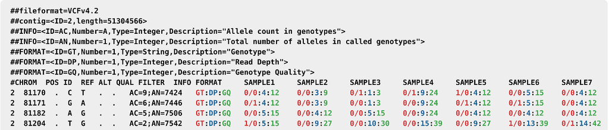

**`INFO` file example**

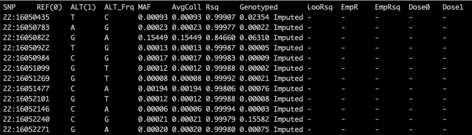

```r
# ---- VCF/INFO files ---- #

# generate VCF file using design matrix as input
vcf <- data.frame(t(X)) # transpose
# dummy values for this example only
vcf$chr <- "chr1"
vcf$pos <- seq(1,1000)
vcf$ID <- snp.Names
vcf$FORMAT <- "DS"
vcf[c('REF', 'ALT', 'QUAL', 'FILTER', 'INFO', 'Sample')] <- rep('.', nrow(vcf))
vcf <- vcf[, c('chr', 'pos', 'ID', 'REF', 'ALT', 'QUAL', 'FILTER', 'INFO', 'FORMAT')]
colnames(vcf) <- c('#CHROM', 'POS', 'ID', 'REF', 'ALT', 'QUAL', 'FILTER', 'INFO', 'FORMAT')
vcfout <- cbind(vcf, data.frame(t(X)))
# write.table(vcfout, "./data/alcohol.vcf", quote = F, row.names = F, col.names = T, sep = "\t")

# Generate INFO file
info <- vcf[, c('ID', 'REF', 'ALT')]
info[c('AAF', 'MAF', 'AvgCall', 'Rsq')] <- rep(0.9, nrow(vcf))
info$Genotyped = "imputed"
info[c('LooRsq', 'EmpR', 'EmpRsq', 'Dose0', 'Dose1')] = "-"
info <- info[, c('ID', 'REF', 'ALT', 'AAF', 'MAF', 'AvgCall', 'Rsq', 'Genotyped', 'LooRsq', 'EmpR', 'EmpRsq', 'Dose0', 'Dose1')]
colnames(info) <- c('SNP', 'REF(0)', 'ALT(1)', 'ALT_Frq', 'MAF', 'AvgCall', 'Rsq', 'Genotyped', 'LooRsq', 'EmpR', 'EmpRsq', 'Dose0', 'Dose1')
# write.table(info, "./data/alcohol.info", quote = F, row.names = F, col.names = T, sep = "\t")

# ---------------------------------- #
# ---- output BinaryDosage file ---- #
# ---------------------------------- #
library(BinaryDosage)
# BinaryDosage::vcftobd(vcffiles = c("interaction/data/alcohol.vcf", './data/alcohol.info'), gz = FALSE, bdfiles = "./data/alcohol.bdose")

# ------------------------------- #
# ---- output covariate file ---- #
# ------------------------------- #
# create covariate file with indicator variables for factors
# make sure it fits requirements specified in GxEScanR documentation
covariates <- c("hs_bmi_c_cat", "h_mbmi_None",
"e3_sex_None", "h_age_None", "h_cohort", "h_edumc_None", "ethn_PC1",
"ethn_PC2",  "e3_alcpreg_yn_None")

# create indicator variables
dataset_gxescan <- data.frame(model.matrix(as.formula(paste("~-1+", paste(covariates, collapse = "+"))), data = dataset))
dataset_gxescan <- dataset_gxescan[ , -which(colnames(dataset_gxescan) %in% "hs_bmi_c_catThin.Normal")]
ID <- paste0("X", seq(1, 1122, 1))
dataset_gxescan <- cbind(ID, dataset_gxescan)

# write.table(dataset_gxescan, "./data/epidata_alcohol.txt", row.names = F, quote = F, sep = '\t')
```

## Run GxEScanR

```r
library(GxEScanR)

# Run GxEScanR
# following code block from John by email on 4/5/22

# remove.packages("BinaryDosage")
# install.packages("BinaryDosage")
library(BinaryDosage)
starttime <- Sys.time()
x <- getbdinfo("./data/alcohol.bdose")
endtime <- Sys.time()
endtime - starttime
```

```
## Time difference of 0.004720688 secs
```

```r
bdinfo <- BinaryDosage::getbdinfo("./data/alcohol.bdose")
epidata <- read.table("./data/epidata_alcohol.txt", stringsAsFactors = F, header = T)

start = Sys.time()
output <- GxEScanR::gweis(data = epidata, bdinfo = bdinfo)
```

```
## [1] "1122 subjects have complete data"
```

```r
stop = Sys.time() - start; stop
```

```
## Time difference of 4.981289 mins
```

```r
# create EDGE statistic for two-step method
output$lrtedge = output$lrtdg + output$lrteg
```

## Post-processing

A quick look at `GxEScanR` output:

```r
kable(head(output)) %>%
   kable_styling(bootstrap_options = c("striped", "hover"), full_width = F, position = 'left')
```

| snp | betadg | lrtdg | betagxe | lrtgxe | lrt2df | betaeg | lrteg | lrt3df | betacase | lrtcase | betactrl | lrtctrl | lrtedge |
| --- | --- | --- | --- | --- | --- | --- | --- | --- | --- | --- | --- | --- | --- |
| SNP.1 | 0.0749726 | 0.4211911 | 0.1818170 | 0.5240537 | 0.9452448 | 0.0658514 | 0.3158712 | 1.2611160 | 0.0516503 | 0.0532057 | 0.1005141 | 0.5081546 | 0.7370623 |
| SNP.2 | 0.0365660 | 0.0724968 | 0.4301339 | 2.1101264 | 2.1826232 | 0.0868622 | 0.3930484 | 2.5756716 | 0.2260055 | 0.7162641 | 0.0402127 | 0.0595261 | 0.4655452 |
| SNP.3 | 0.0370628 | 0.1256276 | 0.3730735 | 2.5363256 | 2.6619532 | 0.0590307 | 0.3019609 | 2.9639140 | 0.2247721 | 1.1678512 | 0.0027905 | 0.0004770 | 0.4275884 |
| SNP.4 | 0.0808729 | 0.6983601 | 0.2653143 | 1.5366766 | 2.2350366 | 0.0188641 | 0.0365518 | 2.2715884 | 0.0397589 | 0.0418872 | 0.0174630 | 0.0226128 | 0.7349118 |
| SNP.5 | 0.0686623 | 0.4090673 | 0.4611555 | 3.6694038 | 4.0784711 | 0.0276943 | 0.0655006 | 4.1439717 | 0.1733491 | 0.6252844 | -0.0188130 | 0.0221728 | 0.4745679 |
| SNP.6 | -0.0616904 | 0.1218617 | 0.2003390 | 0.2828116 | 0.4046733 | -0.0472336 | 0.0679839 | 0.4726572 | -0.0362884 | 0.0104481 | -0.0509180 | 0.0566850 | 0.1898456 |

`GxEScanR` output contains the following:

- `betadg`, `lrtdg` - GWAS estimate + LRT statistic
- `betagxe`, `lrtgxe` - GxE estimate + LRT statistic (traditional logistic regression)
- `lrt2df` - 2DF LRT statistic
- `betaeg`, `lrteg` - G-E association estimate + LRT statistic in combined case+control sample
- `lrt3df` - 3DF LRT statistic
- `betacase`, `lrtcase` - G-E association estimate + LRT statistic in cases only (case-only analysis)
- `betactrl`, `lrtctrl` - G-E association estimate + LRT statistic in controls only

### Example - genotype main effect (GWAS)

We can look at the Q-Q / Manhattan plots of genotype main effects:

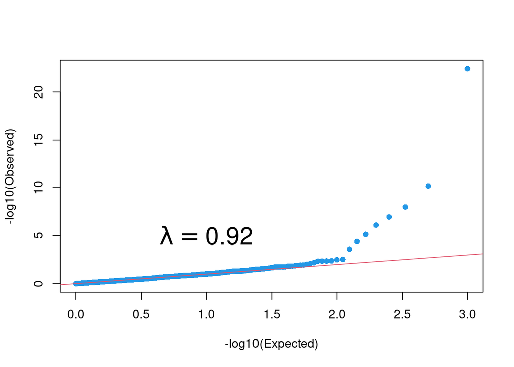

```r
pvalues <- pchisq(output[, 'lrtdg'], df = 1, lower.tail = F)
r <- gcontrol2(pvalues, pch=16)
lambda <- round(r$lambda,3)
text(x=1, y=5, labels=bquote(lambda == .(lambda)), cex=2)
```

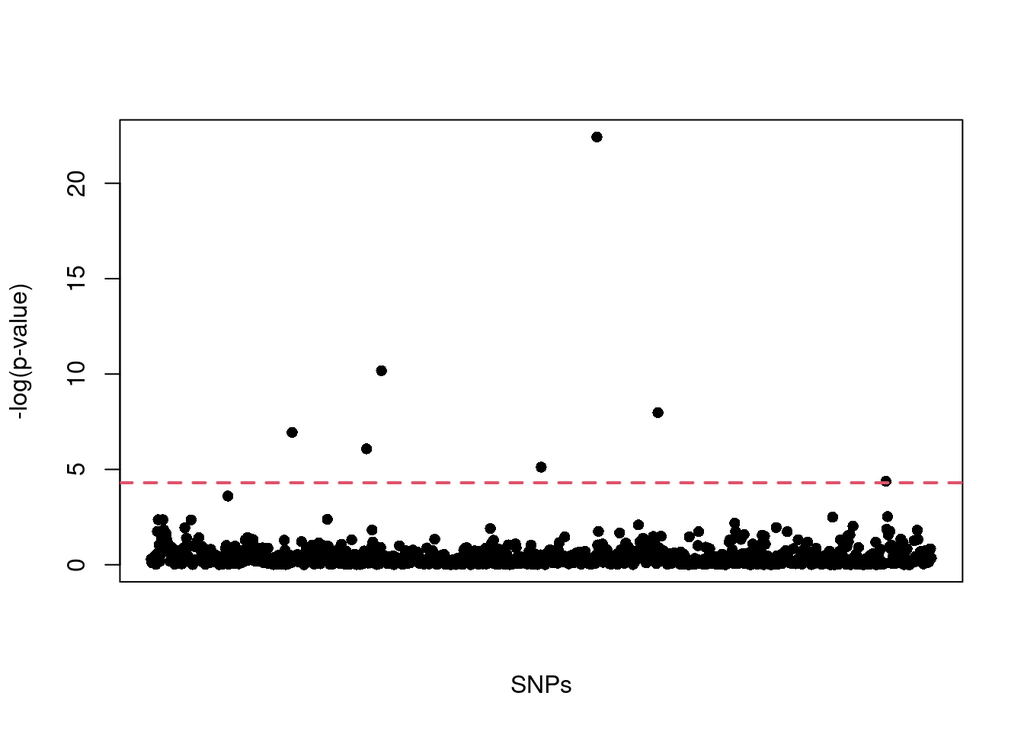

```r
neglog.pvalues <- -log10(pchisq(output[,"lrtdg"], lower.tail = F, df = 1))
plot(1:nrow(output), neglog.pvalues,
     pch=16, xaxt="n", ylim=c(0, max(neglog.pvalues, 3)),
     ylab="-log(p-value)", xlab="SNPs")
abline(h=-log10(0.05/nrow(output)), lty=2, lwd=2, col=2)
```

### Example - GxE test (GWIS)

GxE interaction Q-Q / Manhattan plots

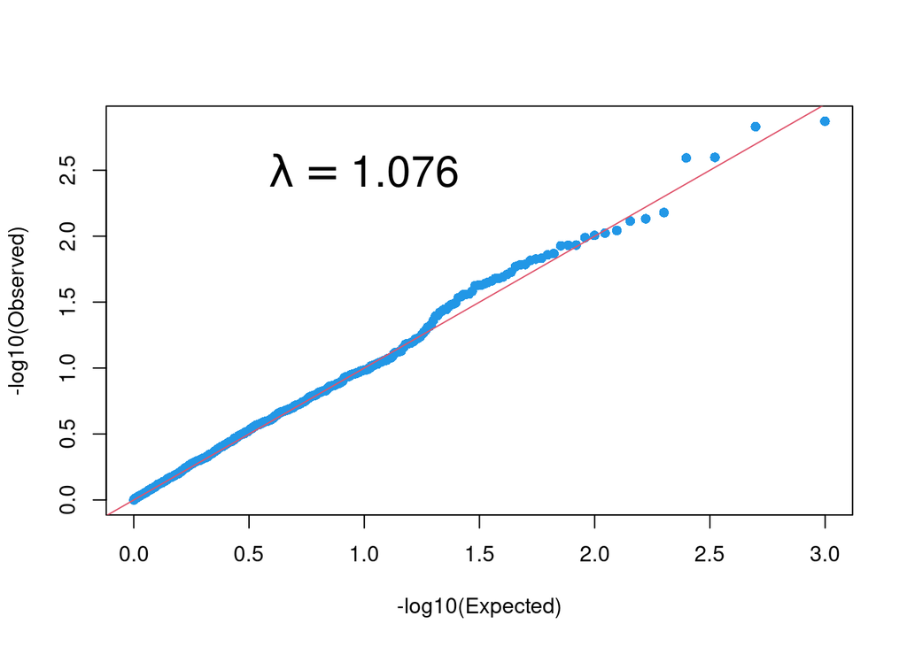

```r
pvalues <- pchisq(output[, 'lrtgxe'], df = 1, lower.tail = F)
r <- gcontrol2(pvalues, pch=16)
lambda <- round(r$lambda,3)
text(x=1, y=2.5, labels=bquote(lambda == .(lambda)), cex=2)
```

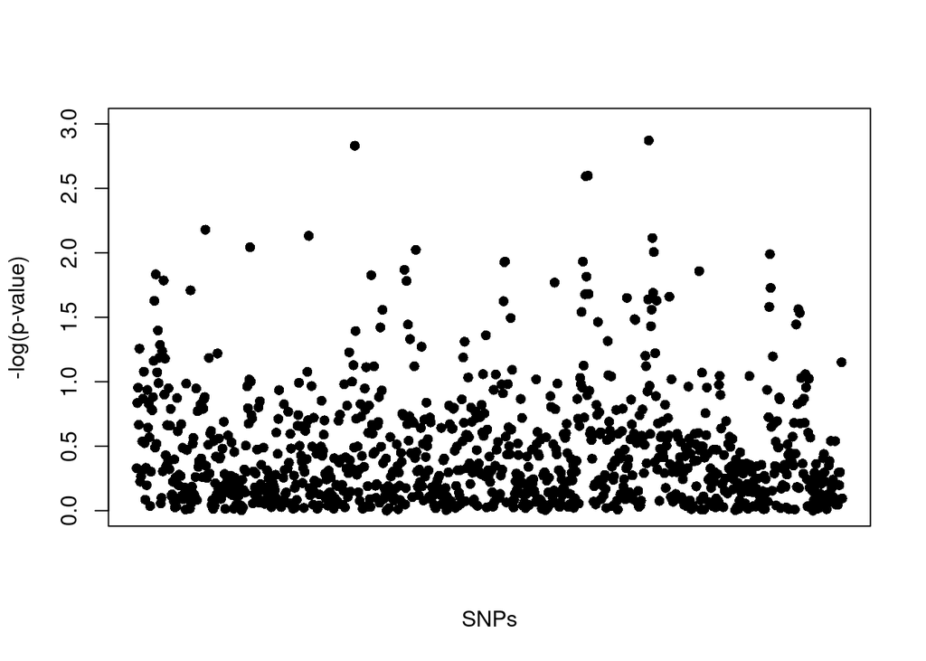

```r
neglog.pvalues <- -log10(pchisq(output[,"lrtgxe"], lower.tail = F, df = 1))
plot(1:nrow(output), neglog.pvalues,
     pch=16, xaxt="n", ylim=c(0, max(neglog.pvalues, 3)),
     ylab="-log(p-value)", xlab="SNPs")
abline(h=-log10(0.05/nrow(output)), lty=2, lwd=2, col=2)
```

### Example - joint G, GxE test (2DF)

2DF test (Kraft et al 2007)

$$logit(P(D=1|G,E)) = \alpha + \beta_EE +
\beta_GG + \beta_{GxE}G\times E$$
where we test the hypothesis $\beta_G = \beta_{GxE} = 0$

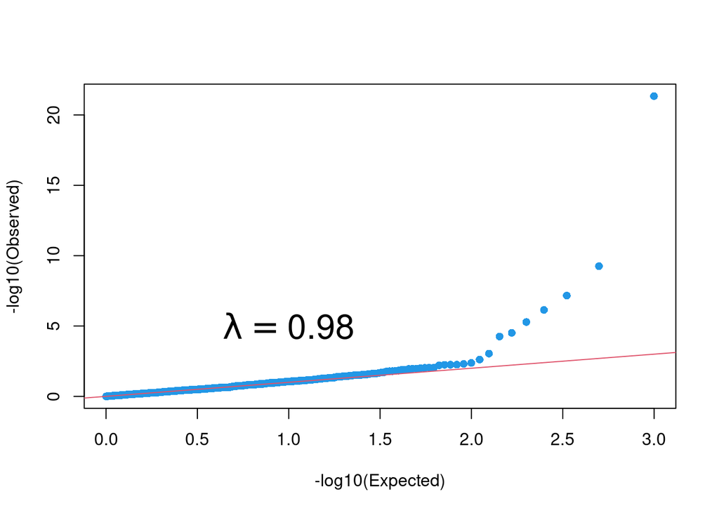

```r
pvalues <- pchisq(output[, 'lrt2df'], df = 2, lower.tail = F)
r <- gcontrol2(pvalues, pch=16)
lambda <- round(r$lambda,3)
text(x=1, y=5, labels=bquote(lambda == .(lambda)), cex=2)
```

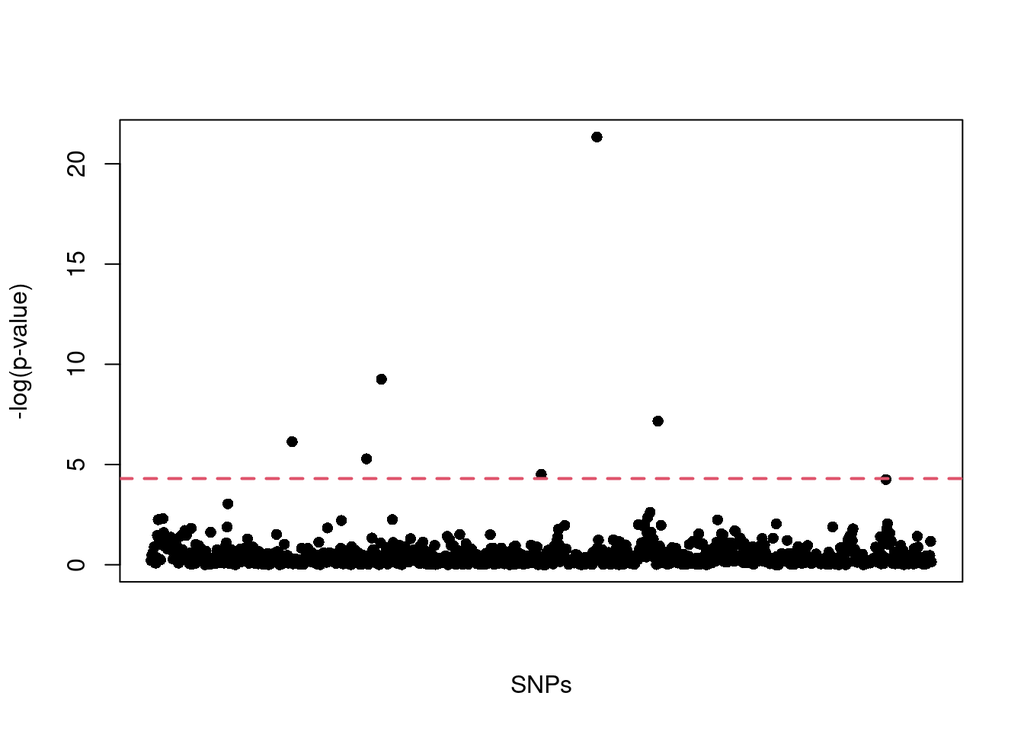

```r
neglog.pvalues <- -log10(pchisq(output[,"lrt2df"], lower.tail = F, df = 2))
plot(1:nrow(output), neglog.pvalues,
     pch=16, xaxt="n", ylim=c(0, max(neglog.pvalues, 3)),
     ylab="-log(p-value)", xlab="SNPs")
abline(h=-log10(0.05/nrow(output)), lty=2, lwd=2, col=2)
```

### Example - joint G, GxE, G vs E (case+control) test (3DF)

Test the hypothesis $\beta_G = \beta_{GxE} = \gamma_G = 0$

where $\gamma_G$ is the G vs E association in combined case/control sample (see Murcray 2009, Gauderman 2019)

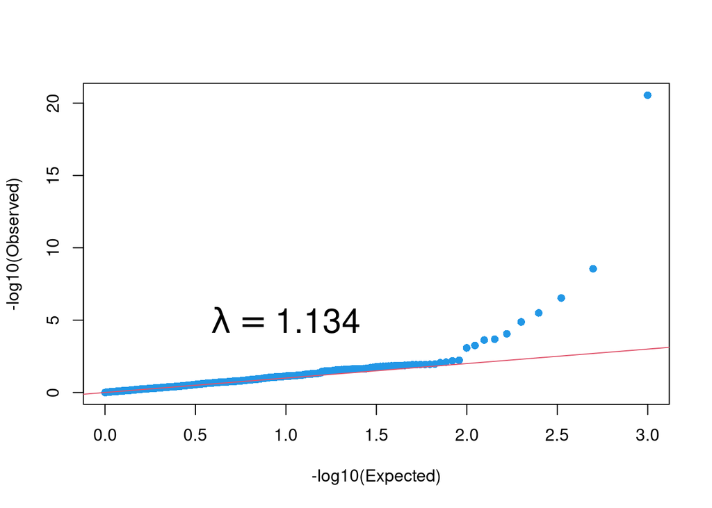

```r
pvalues <- pchisq(output[, 'lrt3df'], df = 3, lower.tail = F)
r <- gcontrol2(pvalues, pch=16)
lambda <- round(r$lambda,3)
text(x=1, y=5, labels=bquote(lambda == .(lambda)), cex=2)
```

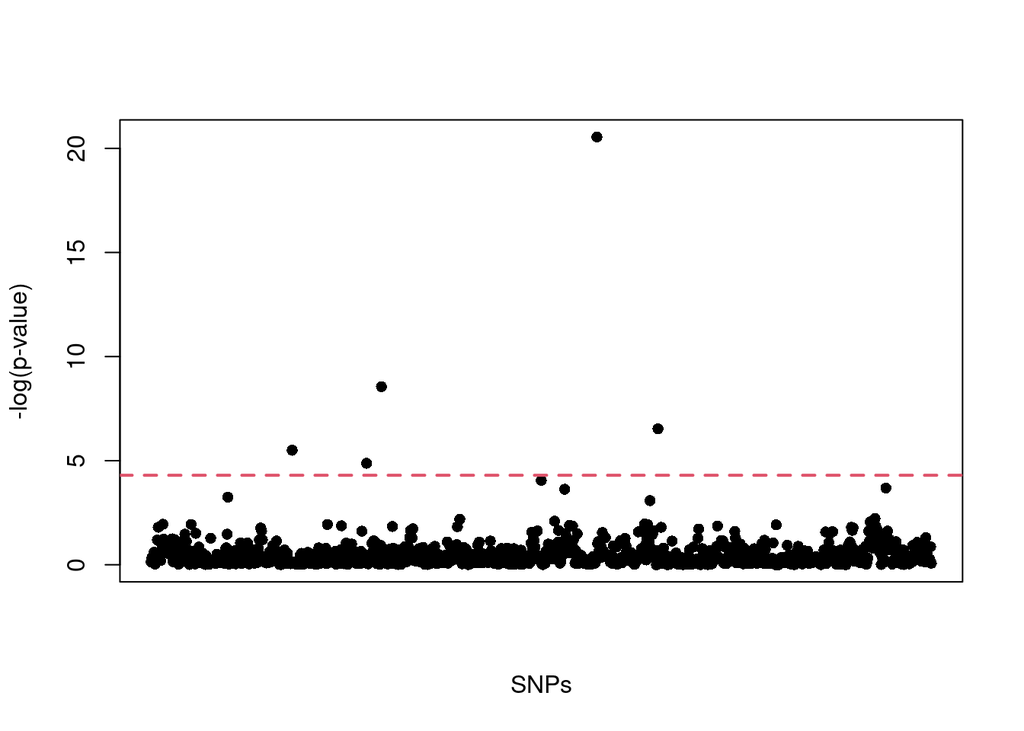

```r
neglog.pvalues <- -log10(pchisq(output[,"lrt3df"], lower.tail = F, df = 3))
plot(1:nrow(output), neglog.pvalues,
     pch=16, xaxt="n", ylim=c(0, max(neglog.pvalues, 3)),
     ylab="-log(p-value)", xlab="SNPs")
abline(h=-log10(0.05/nrow(output)), lty=2, lwd=2, col=2)
```

### Two-step methods

We can use marginal statistics (D|G main effect) to filter SNPs prior to conducting GxE testing. For example, filter SNPs based on their D|G statistic at a $\alpha < 0.05$ level:

```r
# calculate p-values, filter at alpha < 0.05 threshold
output$step1_pvalue <- pchisq(output$lrtdg, lower.tail = F, df = 1)
output$step2_pvalue <- pchisq(output$lrtgxe, lower.tail = F, df = 1)
output_filter <- output[which(output$step1_pvalue < 0.05), ]

# check GxE significance in smaller subset (N = 62)
output_filter$pvalue_bonferroni <- p.adjust(output_filter$step2_pvalue, method = 'bonferroni')
output_filter_significant <- output_filter[which(output_filter$pvalue_bonferroni < 0.05),]

output_filter_significant # EMPTY
```

| snp | betadg | lrtdg | betagxe | lrtgxe | lrt2df | betaeg | lrteg | lrt3df | betacase | lrtcase | betactrl | lrtctrl | lrtedge | step1_pvalue | step2_pvalue | pvalue_bonferroni |
| --- | --- | --- | --- | --- | --- | --- | --- | --- | --- | --- | --- | --- | --- | --- | --- | --- |

*Why did we choose $\alpha < 0.05$ for subset testing? Is there an optimal choice?*

### Two-step methods - weighted hypothesis testing

Rather than choosing an $\alpha$ cut-off, we can include all SNPs by using the step 1 statistic to weight step 2 testing. This way, we do not need to make a decision regarding the appropriate step 1 p-value cutoff, while still maintaining overall $\alpha = 0.05$.

We use the weighted hypothesis testing framework described in Ionita-Laza et al (2007). Specifically, we partition SNPs into exponentially larger bins (with an initial bin size of 5), each with an increasingly more stringent step 2 significance threshold. Essentially, we are giving ‘preferential treatment’ to SNPs with strong step 1 statistics, and testing them at a lower interaction significance threshold.

The partitioning scheme from Ionita-Laza is as follows:

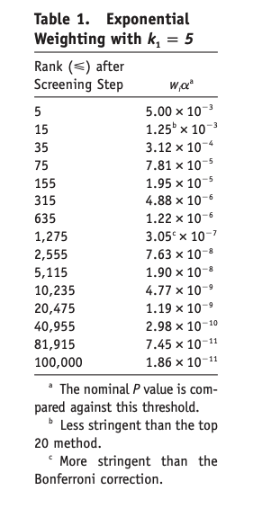

Now onto our results - we partition SNPs into bins and check for significance

```r
# ---- create exponential bins ---- #
sizeBin0 = 5 # initial bin size = 5
m = 997 # number of SNPs
nbins = ceiling(log2(m/sizeBin0 + 1)) # 8 bins to accommodate 1000 SNPs
sizeBin = c(sizeBin0 * 2^(0:(nbins-2)), m - sizeBin0 * (2^(nbins-1) - 1) )

# ---- sort by step 1 statistic (in this case, lrtdg), assign bins ---- #
endpointsBin = cumsum(sizeBin)
bin <- ceiling(log(c(1:m)/sizeBin0+1,base=2))
alphaBin = 0.05 * 2 ^ -(1:nbins) / sizeBin
alphaBin_dat <- rep(alphaBin, table(bin))


# ---- some checks ---- #
table(bin) # bin sizes
```

```
## bin
##   1   2   3   4   5   6   7   8
##   5  10  20  40  80 160 320 362
```

```r
table(alphaBin) # bin step 2 sig threshold
```

```
## alphaBin
## 5.3953729281768e-07     1.220703125e-06       4.8828125e-06        1.953125e-05
##                   1                   1                   1                   1
##          7.8125e-05           0.0003125             0.00125               0.005
##                   1                   1                   1                   1
```

```r
sum(alphaBin * sizeBin) # overall alpha
```

```
## [1] 0.04980469
```

```r
# ---- assign bins, check for significance ---- #
# sort by lrtdg statistic
output_twostep <- output[order(-output[,'lrtdg']), ]
output_twostep$bin_number <- bin
output_twostep$step2p_sig <- as.numeric(alphaBin_dat)

# IN THIS CASE - NO significant interactions
output_twostep_significant <- output_twostep[which(output_twostep$step2p_pvalue < output_twostep$step2p_sig),]

kable(output_twostep_significant) %>%
  kable_styling(bootstrap_options = c("striped", "hover"), full_width = F)
```

| snp | betadg | lrtdg | betagxe | lrtgxe | lrt2df | betaeg | lrteg | lrt3df | betacase | lrtcase | betactrl | lrtctrl | lrtedge | step1_pvalue | step2_pvalue | bin_number | step2p_sig |
| --- | --- | --- | --- | --- | --- | --- | --- | --- | --- | --- | --- | --- | --- | --- | --- | --- | --- |

Visualizing two-step method bins + SNPs is helpful:

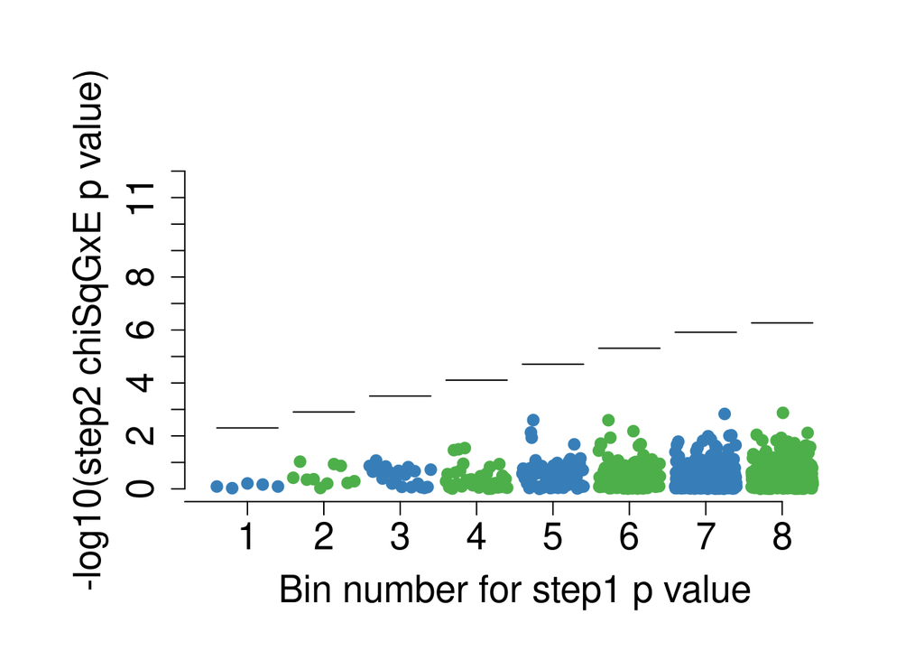

```r
# calculate log pvalues for plotting
output_twostep$log_step2p        <- -log10(output_twostep$step2_pvalue)
output_twostep$log_step2p_siglvl <- -log10(output_twostep$step2p_sig)
output_twostep_plot                   <- split(output_twostep, f = list(output_twostep$bin_number))

# create 'base pair' for each bin so SNPs are plotting evenly
create_mapinfo <- function(x) {
    mapinfo <- seq(unique(x$bin_number) - 1 + 0.1, unique(x$bin_number) - 1 + 0.9, length.out = nrow(x))
    out <- cbind(x, mapinfo)
    return(out)
  }
output_twostep_plot <- lapply(output_twostep_plot, create_mapinfo)


# PLOT
binsToPlot = length(output_twostep_plot)
color <- rep(c("#377EB8","#4DAF4A"),100)
par(mar=c(6, 7, 6, 3))
bin_to_plot = output_twostep_plot[[1]]
plot(bin_to_plot$mapinfo, bin_to_plot$log_step2p,
     col = ifelse(bin_to_plot$snp %in% output_twostep_significant[, 'snp'], '#E41A1C','#377EB8'),
     pch = ifelse(bin_to_plot$snp %in% output_twostep_significant[, 'snp'], 19, 20),
     cex = ifelse(bin_to_plot$snp %in% output_twostep_significant[, 'snp'], 1.3, 1.7),
     xlab="Bin number for step1 p value",
     ylab="-log10(step2 chiSqGxE p value)",
     xlim=c(0, binsToPlot),
     ylim=c(0, 12),
     axes=F,
     cex.main = 1.7,
     cex.axis = 1.7,
     cex.lab = 1.7,
     cex.sub = 1.7)
lines(bin_to_plot$mapinfo, bin_to_plot$log_step2p_siglvl, col = "black", lwd=1)

# remaining bins
for(i in 2:binsToPlot) {
  bin_to_plot = output_twostep_plot[[i]]
  points(bin_to_plot$mapinfo, bin_to_plot$log_step2p,
         col = ifelse(bin_to_plot$snp %in% output_twostep_significant$snp, '#E41A1C', color[i]),
         pch = ifelse(bin_to_plot$snp %in% output_twostep_significant$snp, 19, 20),
         cex = ifelse(bin_to_plot$snp %in% output_twostep_significant$snp, 1.3, 1.7),
         cex.main = 1.7,
         cex.axis = 1.7,
         cex.lab = 1.7,
         cex.sub = 1.7)
  lines(bin_to_plot$mapinfo, bin_to_plot$log_step2p_sig, col = "black",lwd = 1)
}
axis(1, at = c(-1.5, seq(0.5, binsToPlot-0.2, 1)), label = c(0, seq(1, binsToPlot, 1)), cex.axis = 1.7)
axis(2, at = c(0:floor(12)), label = c(0:12), cex.axis=1.7)
```

Let’s look at all the results for alcohol X gene analysis now. I wrapped all the steps above in functions for convenience, you can refer to them in the file `interaction_functions.R`

## Q-Q plots

### D|G

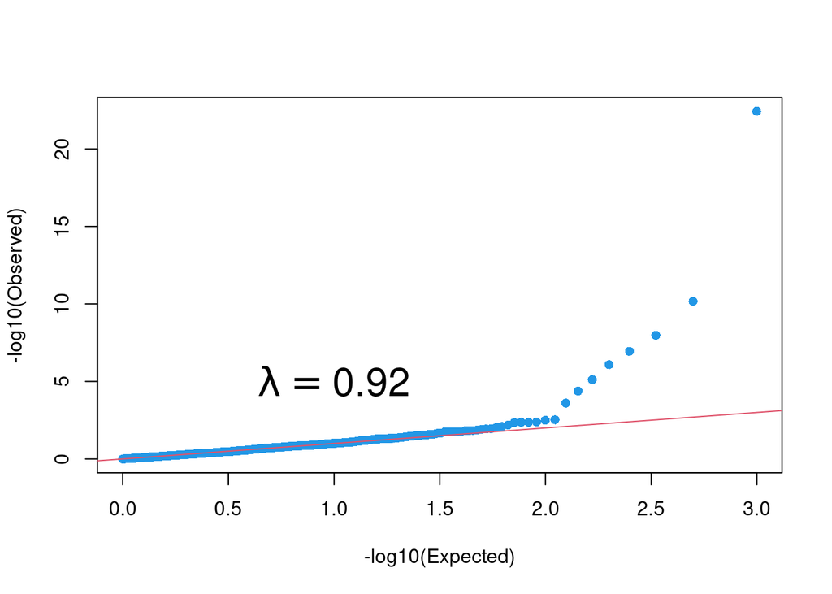

```r
plot_qq(output, 'lrtdg', 1)
```

### GxE

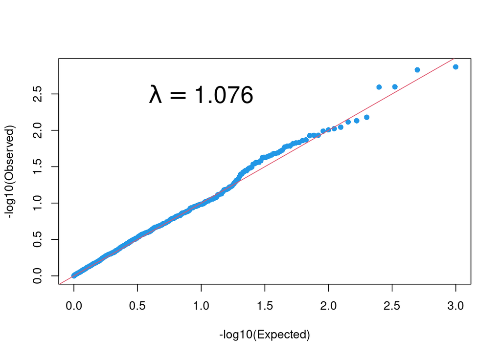

```r
plot_qq(output, 'lrtgxe', 1, print_yloc = 2.5)
```

### Case only

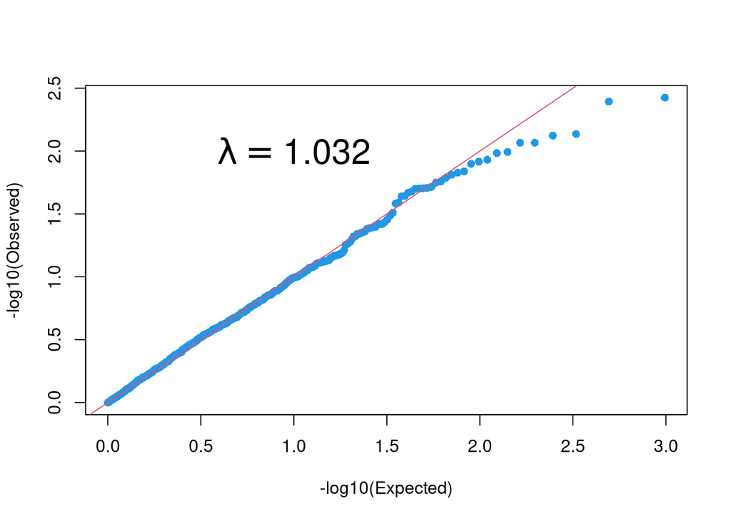

```r
plot_qq(output, 'lrtcase', 1, print_yloc = 2)
```

### 2DF

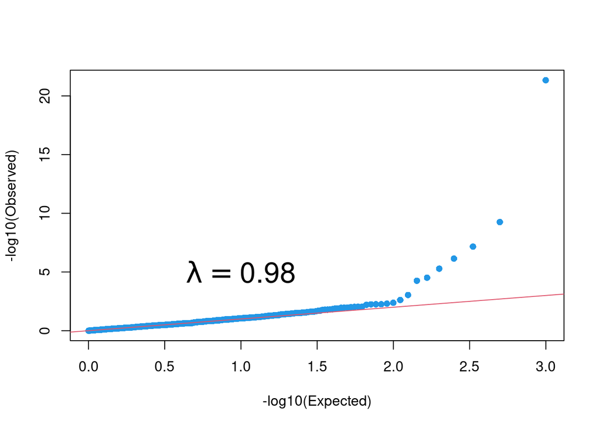

```r
plot_qq(output, 'lrt2df', 2)
```

### 3DF

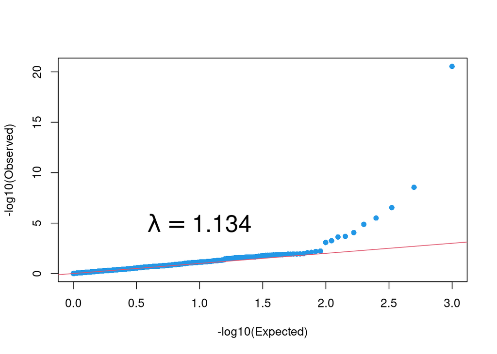

```r
plot_qq(output, 'lrt3df', 3)
```

## Manhattan plots

### D|G

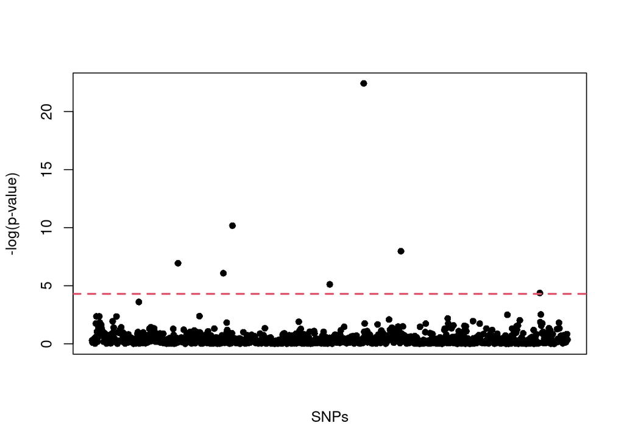

```r
plot_manhattan(output, 'lrtdg', 1)
```

```r
kable(sig_table(output, 'lrtdg', 1)) %>% kable_styling(bootstrap_options = c("striped", "hover"), full_width = F, position = 'left')
```

|  | snp | lrtdg_pval | lrtgxe_pval | lrt2df_pval | lrteg_pval | lrtctrl_pval | lrtcase_pval | lrt3df_pval |
| --- | --- | --- | --- | --- | --- | --- | --- | --- |
| 181 | SNP.183 | 1.1459e-07 | 6.8429e-01 | 7.2446e-07 | 9.4921e-01 | 8.3911e-01 | 6.2487e-01 | 3.1727e-06 |
| 276 | SNP.278 | 8.3274e-07 | 8.1480e-01 | 5.1954e-06 | 3.2564e-01 | 4.9653e-01 | 3.0262e-01 | 1.3353e-05 |
| 295 | SNP.297 | 6.6784e-11 | 9.4069e-01 | 5.5712e-10 | 7.1133e-01 | 9.1078e-01 | 8.6978e-01 | 2.7762e-09 |
| 499 | SNP.502 | 7.6514e-06 | 3.8074e-01 | 3.0564e-05 | 4.4388e-01 | 1.8817e-01 | 4.1470e-01 | 8.7878e-05 |
| 570 | SNP.573 | 3.7539e-23 | 8.1420e-01 | 4.5809e-22 | 4.7419e-01 | 8.9811e-01 | 4.8411e-01 | 2.8401e-21 |
| 648 | SNP.651 | 1.0438e-08 | 6.2329e-01 | 6.8281e-08 | 6.9320e-01 | 6.0614e-01 | 8.1540e-01 | 2.9872e-07 |
| 939 | SNP.942 | 4.2118e-05 | 9.3578e-02 | 5.5864e-05 | 9.4428e-01 | 4.5410e-01 | 5.3258e-01 | 2.0640e-04 |

### GxE

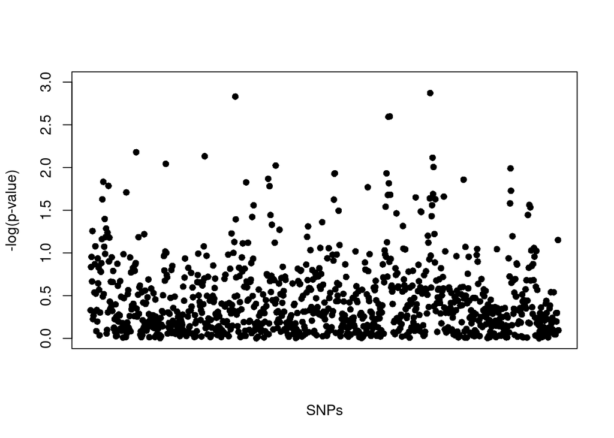

```r
plot_manhattan(output, 'lrtgxe', 1)
```

```r
kable(sig_table(output, 'lrtgxe', 1)) %>%  kable_styling(bootstrap_options = c("striped", "hover"), full_width = F, position = 'left')
```

| snp | lrtdg_pval | lrtgxe_pval | lrt2df_pval | lrteg_pval | lrtctrl_pval | lrtcase_pval | lrt3df_pval |
| --- | --- | --- | --- | --- | --- | --- | --- |

### Case-only

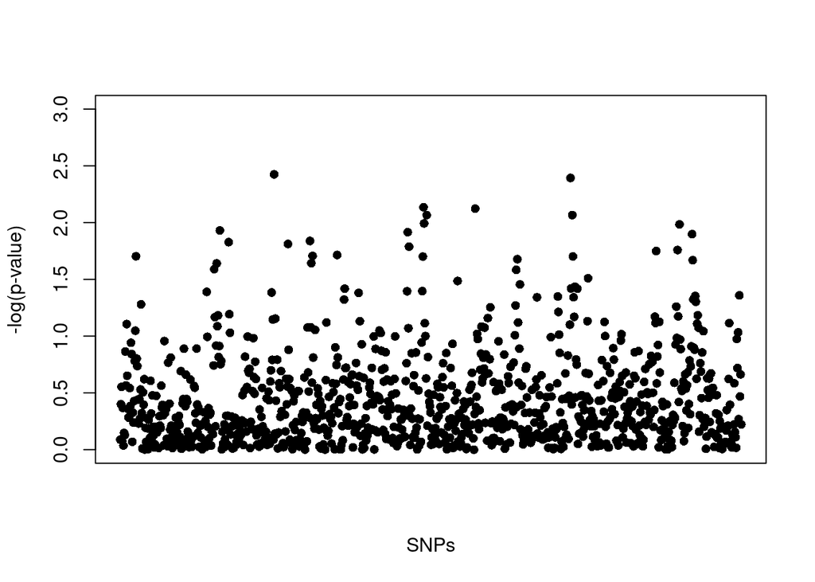

```r
plot_manhattan(output, 'lrtcase', 1)
```

### 2DF

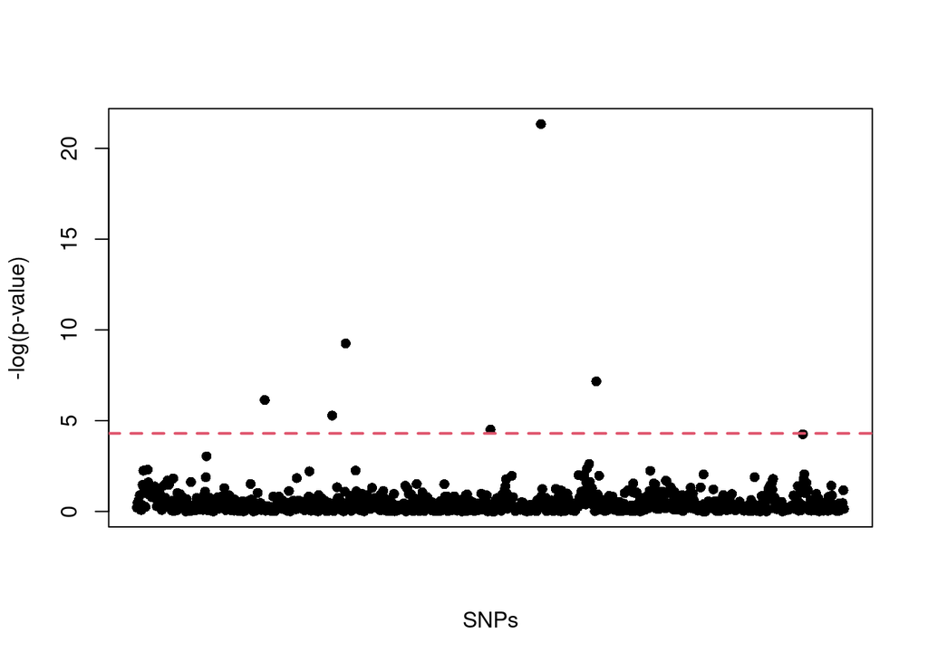

```r
plot_manhattan(output, 'lrt2df', 2)
```

### 3DF

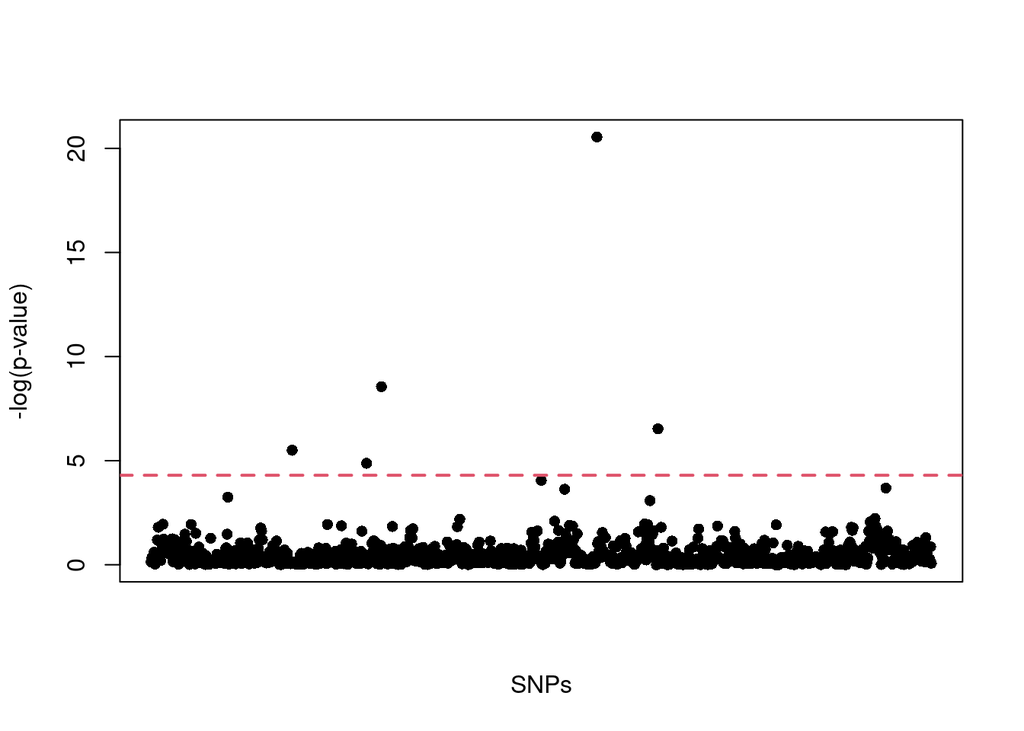

```r
plot_manhattan(output, 'lrt3df', 3)
```

## Two-step methods

### Twostep D|G

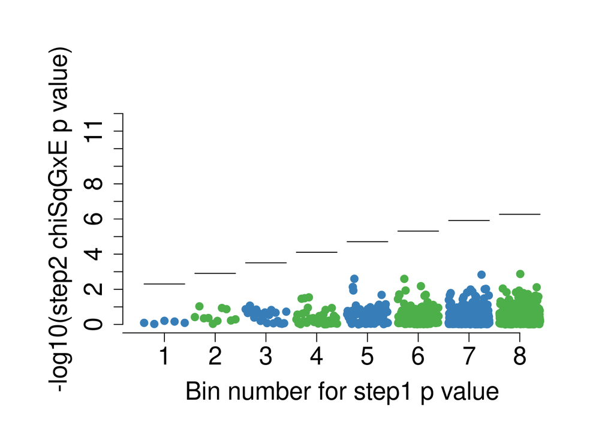

```r
plot_twostep(output, step1_statistic = 'lrtdg', step1_df = 1, sizeBin0 = 5, alpha = 0.05)
```

```r
kable(sig_twostep(output, step1_statistic = 'lrtdg', step1_df = 1, sizeBin0 = 5, alpha = 0.05)) %>% kable_styling(bootstrap_options = c("striped", "hover"), full_width = F, position = 'left')
```

| snp | step1_pval | step2_pval |
| --- | --- | --- |

### Twostep E|G

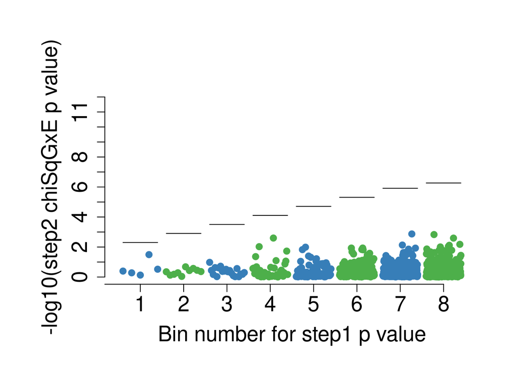

```r
plot_twostep(output, step1_statistic = 'lrteg', step1_df = 1, sizeBin0 = 5, alpha = 0.05)
```

```r
kable(sig_twostep(output, step1_statistic = 'lrteg', step1_df = 1, sizeBin0 = 5, alpha = 0.05)) %>% kable_styling(bootstrap_options = c("striped", "hover"), full_width = F, position = 'left')
```

| snp | step1_pval | step2_pval |
| --- | --- | --- |

### Twostep EDGE

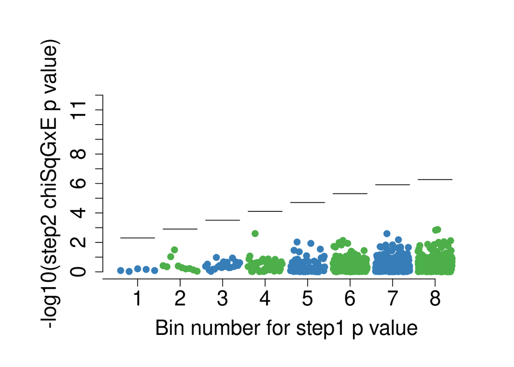

```r
plot_twostep(output, step1_statistic = 'lrtedge', step1_df = 2, sizeBin0 = 5, alpha = 0.05)
```

```r
kable(sig_twostep(output, step1_statistic = 'lrtedge', step1_df = 2, sizeBin0 = 5, alpha = 0.05)) %>% kable_styling(bootstrap_options = c("striped", "hover"), full_width = F, position = 'left')
```

| snp | step1_pval | step2_pval |
| --- | --- | --- |

Your turn

# G x Maternal smoking and childhood BMI

Follow the analysis pipeline in **G x Maternal Alcohol use and childhood BMI**, perform GxE analysis using `GxEScanR` to assess interactions between maternal smoking + genetic variants in determining childhood BMI. All necessary files and functions are provided for expediency. Below are the two questions we are trying to answer:

1. How many interactions between smoking and SNPs do you identify with traditional logistic regression?
2. How many interactions do you identify using two-step methods?

## Run GxEScanR

```r
# 1. read in bdinfo by using getbdinfo

# 2. read in epidata by using read.table

# 3. run GxEScanR using gweis
```

## Generate plots and tables

Focus on GxE + two-step methods

```r
# GxE



# Two-step method - filter by genetic main effect



# Two-step method - filter by gene | exposure association among combined case/control population


# Two-step method - filter by EDGE statistic
```